# *Naives Bayes: Supervised Machine Learning*

## *What is Naives Bayes?*

*Naive Bayes is a classification technique based on **Bayes’ Theorem(Probability theory)** with an assumption that all the features that predicts the target value are independent of each other. In simple terms, a Naive Bayes classifier assumes that the presence of a particular feature in a class is unrelated to the presence of any other feature in determining the target value.*

*This assumption we just read about is very Naive when we are dealing with real world data because most of the times, features do depend on each other in determining the target - this is why the algorithm gets its name Naive Bayes.*

*The typical example use-case for this algorithm is classifying email messages as spam or “ham” (non-spam) based on the previously observed frequency of words which have appeared in known spam or ham emails in the past. Other use cases where naive bayes is heavily used is Text Classification, Medical Diagnosis, RSS Feeds, Weather Prediction, etc.*

*It has many different configurations namely:*

- *Gaussian NB* *– The likelihood of the features is assumed to be Gaussian distribution.*
- *Multinomial NB* *– This works for multinomially distributed data like word count vector where features in the vectors are probability of the event appearing in the sample.*
- *Bernoulli NB* *– This is used for multivariate Bernoulli distributions; i.e., there may be multiple features but each one is assumed to be a binary-valued (boolean) variable.*

*In spite of this oversimplified assumption, naive Bayes classifiers work very well in many complex real-world problems. A big advantage of naive Bayes classifiers is that they only require a relatively small number of training data samples to perform classification efficiently, compared to other algorithms like logistic regression, decision trees, and support vector machines.*

## *Conditional Probability and Bayes’ Theorem*

*In the simplest terms, conditional probability, denoted as P(O|E) and read as probability of outcome O given event E, is the probability of the occurrence of an outcome O given that some other event E has already occurred. It is calculated as:*

$$P(O|E) = \frac{P(O\thinspace\cap E)}{P(E)}$$

$P(O\cap E)$ *is the probability that both O and E occur; this is the same as calculating P(O) , the probability of O occurring multiplied by P(E|O) , the probability of E occurring given that O has already occurred, or conversely P(E) , the probability of E occurring multiplied by P(O|E) , the probability of O occurring given that E has occurred.*

$$P(O\cap E) = P(O) * P(E|O) = P(E) * P(O|E)$$

*The equality of the two terms on the right leads to the **Bayes’ Theorem**.*

$$P(O|E) = \frac{P(E|O) \thinspace*\thinspace P(O)}{P(E)}$$

*Thus, the Bayes’ Theorem is a way to go from P(O|E) to P(E|O) . The above equation is often written as:*

$$posterior \thinspace probability = \frac{likelihood\thinspace*\thinspace prior\thinspace probability}{evidence}$$

*P(O) is also known as a **priori probability** because it is probability of the class (or outcome or model) which is always known a priori from the training examples, while P(O|E) is called the a **posteriori probability** because it is the probability of the class (or model) which we calculate after seeing the data (or evidence or events). **Likelihood** answers the question that “What is the probability of the data (or **evidence or events**) that it has been generated from the model (or class or outcome) ?”*

## *Why is it called “Naive”?*

_So far, we have only talked about the effect of a single event E on the occurrence of outcome O. In reality however, the probability of outcome O’s occurrence is governed by more than one already occurred event. The mathematics behind such a scenario gets very complicated and is made simple by assuming that the various governing events are independent of each other. Mathematically expressing, if an outcome O depends on events $E_1 , E_2 ,…, E_n$ , then assuming $E_1 , E_2 ,…, E_n$ do not depend on one other,_

$$P(O|E_1, E_2,..., E_n)= \frac{P(E_1|O) \thinspace * \thinspace P(E_2|O) \thinspace * \thinspace ... \thinspace * \thinspace P(E_n|O)} {P(E_1) \thinspace * \thinspace P(E_2) \thinspace * \thinspace... \thinspace *\thinspace P(E_n)} P(O) (1)$$

*Thus, the model is very naively believing that the effect of the occurrence of any of the events is completely independent of the occurrence of other events. This is obviously not the case with most of the real world problems and the predictor features are known to influence and be influenced by other features. Still, naive Bayes is known to provide results at par and sometimes even better than highly complex and computationally expensive classification models.*

## *Understanding it with Example*

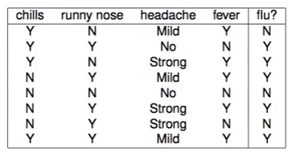

*chills, runny nose, headache and fever* _are features (analogous to the already occurred events E_1, E_2, E_3 and E_4 explained above), while flu and no flu are the two classes C_1 and C_2 in which the above patients were known to be falling (analogous to the two outcomes O_1 and O*2 ). We get a new patient with the following symptoms which are previously unseen by the classifier:*

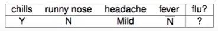

*How to decide whether the patient has flu or not using the naive Bayes’ classifier?*

### **How is the classification done?**

_For the task of classification, we use the training data to determine the prior probabilities of the 2 classes (flu or no flu) and the likelihoods of the 4 events that govern these outcomes. We begin by calculating the likelihoods of each of the event given the class, like $P(chills = N| flu = Y)$ , $P(fever = N| flu = N)$ and so on, just like illustrated in equation 1 above. These values are to be used to determine the posterior probability of the test data belonging to each of the 2 classes, i.e., $P(C_1|E_1, E_2, E_3, E_4)$ and $P(C_2|E_1, E_2, E_3, E_4)$ . The patient is predicted to be belonging to the class for which the value of the calculated posterior probability is higher._

*The various probabilities that we are going to require as per equation 1 for the case when the patient has flu, ie, flu = Y are calculated as below:*

| $P(flu = Y)$ | $\frac{5}{8} = 0.625$ | $P(O)$ |
| --- | --- | --- |
| $P(chills = Y\|flu = Y)$ | $\frac{3}{5} = 0.6$ | $P(E_1\|O)$ |
| $P(runnynose = N\|flu = Y)$ | $\frac{1}{5} = 0.2$ | $P(E_2\|O)$ |
| $P(headache = mild\|flu = Y)$ | $\frac{2}{5} = 0.4$ | $P(E_3\|O)$ |
| $P(fever = N\|flu = Y)$ | $\frac{1}{5} = 0.2$ | $P(E_1\|O)$ |
| $P(chills = Y)$ | $\frac{4}{8} = 0.5$ | $P(E_1)$ |
| $P(runnynose = N)$ | $\frac{3}{8} = 0.375$ | $P(E_2)$ |
| $P(headache = mild)$ | $\frac{3}{8} = 0.375$ | $P(E_3)$ |
| $P(fever = N)$ | $\frac{3}{8} = 0.375$ | $P(E_4)$ |

_Now calculating $P(flu = Y|E_1, E_2, E_3, E_4)$ by plugging these probabilities in (1)_

$$= \frac{0.6 \thinspace *\thinspace 0.2 *\thinspace 0.4 \thinspace* \thinspace0.2}{0.5 \thinspace*\thinspace 0.375 \thinspace*\thinspace 0.375 \thinspace*\thinspace 0.375} 0.625=\thinspace 0.227$$

_Similarly, the various probabilities are calculated for the case of flu = N . The readers are encouraged to calculate these values and check them with the ones used below. Hence $P(flu = N|E_1, E_2, E_3, E_4)$_

$$= \frac{0.33 \thinspace *\thinspace 0.66 *\thinspace 0.33 \thinspace* \thinspace0.66}{0.5 \thinspace*\thinspace 0.375 \thinspace*\thinspace 0.375 \thinspace*\thinspace 0.375} 0.375=\thinspace 0.674$$

*Thus the naive Bayes’ classifier will predict the class flu = N for the above patient because the value of posterior probability was higher for flu = N than for the class flu = Y.*

*If you notice, you can see what the task of prediction eventually reduces to – just calculating some probabilities and a few multiplications. All fairly easy and quick. If you pay even more attention, you see that since the denominator is the same while determining the probabilities of the outcome as either flu or no flu, you can even do away without calculating its value.*

*Thus,* $P(flu = Y|E_1, E_2, E_3, E_4) = 0.6 * 0.4 * 0.2 * 0.2 * 0.625 = \textbf{0.006}$

$P(flu = N|E_1, E_2, E_3, E_4) = 0.33 * 0.66 * 0.33 * 0.66 * 0.375 = \textbf{0.0185}$

*Again, the calculated probabilities give the same prediction as before, ie, **no flu**.*

*This is what makes naive Bayes’ so popular as a classifier, combined with the fact that it has been seen to perform exceptionally well in many applications.*

## *Gaussian Naive Bayes*

### *What is a distribution?*

*Distribution, basically show how values are dispersed in series, and how frequently they appear in this series. Here is an example:*

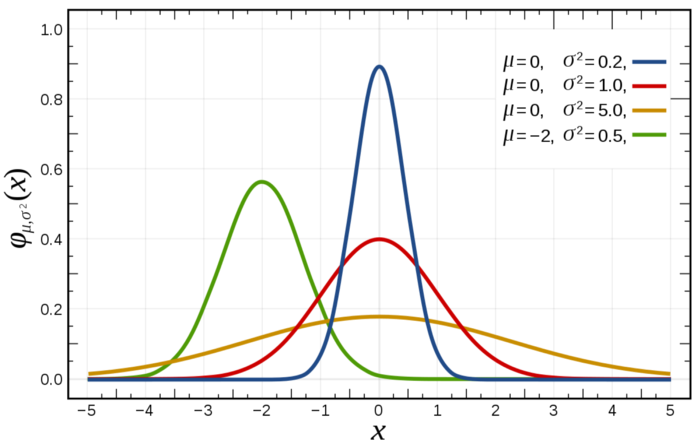

*How you can see in the plot above, the Gaussian or Normal Distribution depends on 2 parameters of a series — The mean and the standard Deviation. Knowing these 2 parameters of the series we can find it’s distribution function. It has the next form:*

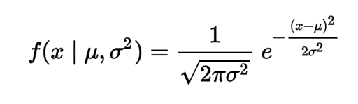

*But, why do we need this function? Very simple, the majority of data in the world is represented as continuous values, but guess what, you can’t calculate the probability of the value X to get the value v. It would be 0. Why? Technically when you divide something by infinity you get what? correct — zero.*

*So, how we can solve this problem? Of course, using the Gaussian Distribution Function, illustrated above. Imputing instead of x their value from a series, the mean value of the series and its standard deviation you can find out the probability that the value x will occur.*

```python
# Packages / libraries

import os #provides functions for interacting with the operating system

import numpy as np
import pandas as pd
from matplotlib import pyplot as plt
import seaborn as sns

%matplotlib inline
import math
import random

import warnings
warnings.filterwarnings('ignore')
```

### *Mathematical Implementation*

```python
# Create an empty dataframe
data = pd.DataFrame()

# Create our target variable
data['Gender'] = ['male','male','male','male','female','female','female','female']

# Create our feature variables
data['Height'] = [6,5.92,5.58,5.92,5,5.5,5.42,5.75]
data['Weight'] = [180,190,170,165,100,150,130,150]
data['Foot_Size'] = [12,11,12,10,6,8,7,9]

# View the data
data
```

|  | Gender | Height | Weight | Foot_Size |
| --- | --- | --- | --- | --- |
| 0 | male | 6.00 | 180 | 12 |
| 1 | male | 5.92 | 190 | 11 |
| 2 | male | 5.58 | 170 | 12 |
| 3 | male | 5.92 | 165 | 10 |
| 4 | female | 5.00 | 100 | 6 |
| 5 | female | 5.50 | 150 | 8 |
| 6 | female | 5.42 | 130 | 7 |
| 7 | female | 5.75 | 150 | 9 |

```python
# Create an empty dataframe
person = pd.DataFrame()

# Create some feature values for this single row
person['Height'] = [6]
person['Weight'] = [130]
person['Foot_Size'] = [8]

# View the data
person
```

|  | Height | Weight | Foot_Size |
| --- | --- | --- | --- |
| 0 | 6 | 130 | 8 |

*Calculate Priors*

*Priors can be either constants or probability distributions. In our example, this is simply the probability of being a gender. Calculating this is simple:*

```python
# Number of males
n_male = data['Gender'][data['Gender'] == 'male'].count()

# Number of males
n_female = data['Gender'][data['Gender'] == 'female'].count()

# Total rows
total_ppl = data['Gender'].count()
```

```python
# Number of males divided by the total rows
P_male = n_male/total_ppl

# Number of females divided by the total rows
P_female = n_female/total_ppl
```

*Calculate Likelihood*

*Remember that each term (e.g. p(height∣female)) in our likelihood is assumed to be a normal pdf. For example:*

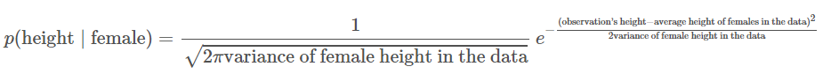

*This means that for each class (e.g. female) and feature (e.g. height) combination we need to calculate the variance and mean value from the data. Pandas makes this easy:*

```python
# Group the data by gender and calculate the means of each feature
data_means = data.groupby('Gender').mean()

# View the values
data_means
```

| Gender | Height | Weight | Foot_Size |
| --- | --- | --- | --- |
| female | 5.4175 | 132.50 | 7.50 |
| male | 5.8550 | 176.25 | 11.25 |

```python
# Group the data by gender and calculate the variance of each feature
data_variance = data.groupby('Gender').var()

# View the values
data_variance
```

| Gender | Height | Weight | Foot_Size |
| --- | --- | --- | --- |
| female | 0.097225 | 558.333333 | 1.666667 |
| male | 0.035033 | 122.916667 | 0.916667 |

```python
# Means for male
male_height_mean = data_means['Height'][data_variance.index == 'male'].values[0]
male_weight_mean = data_means['Weight'][data_variance.index == 'male'].values[0]
male_footsize_mean = data_means['Foot_Size'][data_variance.index == 'male'].values[0]

# Variance for male
male_height_variance = data_variance['Height'][data_variance.index == 'male'].values[0]
male_weight_variance = data_variance['Weight'][data_variance.index == 'male'].values[0]
male_footsize_variance = data_variance['Foot_Size'][data_variance.index == 'male'].values[0]

# Means for female
female_height_mean = data_means['Height'][data_variance.index == 'female'].values[0]
female_weight_mean = data_means['Weight'][data_variance.index == 'female'].values[0]
female_footsize_mean = data_means['Foot_Size'][data_variance.index == 'female'].values[0]

# Variance for female
female_height_variance = data_variance['Height'][data_variance.index == 'female'].values[0]
female_weight_variance = data_variance['Weight'][data_variance.index == 'female'].values[0]
female_footsize_variance = data_variance['Foot_Size'][data_variance.index == 'female'].values[0]
```

*Finally, we need to create a function to calculate the probability density of each of the terms of the likelihood (e.g. p(height∣female)).*

```python
# Create a function that calculates p(x | y):
def p_x_given_y(x, mean_y, variance_y):

    # Input the arguments into a probability density function
    p = 1/(np.sqrt(2*np.pi*variance_y)) * np.exp((-(x-mean_y)**2)/(2*variance_y))

    # return p
    return p
```

*Apply Bayes Classifier To New Data Point*

*Alright! Our bayes classifier is ready. Remember that since we can ignore the marginal probability (the demoninator), what we are actually calculating is this:*

```python
# Numerator of the posterior if the unclassified observation is a male
P_male * \
p_x_given_y(person['Height'][0], male_height_mean, male_height_variance) * \
p_x_given_y(person['Weight'][0], male_weight_mean, male_weight_variance) * \
p_x_given_y(person['Foot_Size'][0], male_footsize_mean, male_footsize_variance)
```

```
6.197071843878078e-09
```

```python
# Numerator of the posterior if the unclassified observation is a female
P_female * \
p_x_given_y(person['Height'][0], female_height_mean, female_height_variance) * \
p_x_given_y(person['Weight'][0], female_weight_mean, female_weight_variance) * \
p_x_given_y(person['Foot_Size'][0], female_footsize_mean, female_footsize_variance)
```

```
0.0005377909183630018
```

*Because the numerator of the posterior for female is greater than male, then we predict that the person is female.*

### *Model using sklearn*

```python
#reading dataset
Data=pd.read_csv(r'C:\Users\PiyushSin\Desktop\datasets\Social_Network_Ads.csv')
Data.head(10)
```

|  | User ID | Gender | Age | EstimatedSalary | Purchased |
| --- | --- | --- | --- | --- | --- |
| 0 | 15624510 | Male | 19 | 19000 | 0 |
| 1 | 15810944 | Male | 35 | 20000 | 0 |
| 2 | 15668575 | Female | 26 | 43000 | 0 |
| 3 | 15603246 | Female | 27 | 57000 | 0 |
| 4 | 15804002 | Male | 19 | 76000 | 0 |
| 5 | 15728773 | Male | 27 | 58000 | 0 |
| 6 | 15598044 | Female | 27 | 84000 | 0 |
| 7 | 15694829 | Female | 32 | 150000 | 1 |
| 8 | 15600575 | Male | 25 | 33000 | 0 |
| 9 | 15727311 | Female | 35 | 65000 | 0 |

```python
from sklearn.model_selection import train_test_split

X = Data[['Gender','Age','EstimatedSalary']]
y = Data[['Purchased']]

X_dummy = pd.get_dummies(X, drop_first=True)

X_train, X_test, y_train, y_test = train_test_split(X_dummy,y,test_size=0.4,random_state=42)
```

```python
from sklearn.naive_bayes import GaussianNB

classifier = GaussianNB()
classifier.fit(X_train, y_train)
```

```
GaussianNB()
```

```python
classifier.score(X_test,y_test)
```

```
0.8875
```

```python
classifier.predict(X_test)
```

```
array([1, 1, 0, 1, 0, 0, 1, 0, 0, 0, 0, 1, 0, 0, 0, 0, 1, 1, 0, 1, 0, 0,
       1, 1, 0, 1, 0, 0, 1, 0, 0, 0, 1, 0, 1, 0, 0, 0, 0, 0, 1, 0, 0, 1,
       0, 1, 0, 0, 0, 0, 0, 1, 0, 0, 0, 0, 1, 0, 0, 0, 0, 0, 1, 0, 0, 1,
       0, 1, 0, 1, 1, 0, 0, 0, 0, 0, 1, 1, 0, 0, 0, 0, 1, 0, 1, 1, 0, 1,
       0, 0, 1, 0, 0, 0, 0, 0, 1, 0, 1, 1, 1, 0, 1, 0, 0, 1, 1, 0, 1, 0,
       0, 0, 1, 1, 1, 0, 0, 0, 0, 0, 0, 0, 0, 1, 0, 0, 0, 0, 0, 1, 0, 0,
       1, 0, 0, 0, 0, 1, 1, 1, 0, 0, 1, 0, 0, 1, 1, 0, 0, 0, 0, 0, 1, 0,
       0, 0, 1, 0, 1, 0], dtype=int64)
```

```python
classifier.predict_proba(X_test)
```

```
array([[0.4943266 , 0.5056734 ],
       [0.04219662, 0.95780338],
       [0.96481656, 0.03518344],
       [0.20177795, 0.79822205],
       [0.94902976, 0.05097024],
       [0.94867678, 0.05132322],
       [0.12824557, 0.87175443],
       [0.9191861 , 0.0808139 ],
       [0.73771235, 0.26228765],
       [0.72351712, 0.27648288],
       [0.89084418, 0.10915582],
       [0.25975564, 0.74024436],
       [0.98213159, 0.01786841],
       [0.98191369, 0.01808631],
       [0.89316644, 0.10683356],
       [0.51999096, 0.48000904],
       [0.31212379, 0.68787621],
       [0.49881698, 0.50118302],
       [0.83482495, 0.16517505],
       [0.16974795, 0.83025205],
       [0.97928658, 0.02071342],
       [0.92923681, 0.07076319],
       [0.46167399, 0.53832601],
       [0.06785129, 0.93214871],
       [0.98205961, 0.01794039],
       [0.28757055, 0.71242945],
       [0.62507329, 0.37492671],
       [0.87646151, 0.12353849],
       [0.00688495, 0.99311505],
       [0.9829224 , 0.0170776 ],
       [0.59215478, 0.40784522],
       [0.98582095, 0.01417905],
       [0.02790435, 0.97209565],
       [0.94031631, 0.05968369],
       [0.34023068, 0.65976932],
       [0.86411198, 0.13588802],
       [0.8749158 , 0.1250842 ],
       [0.83431528, 0.16568472],
       [0.96818983, 0.03181017],
       [0.98780615, 0.01219385],
```

[output cut: 105 more lines]

```
       [0.00508527, 0.99491473],
       [0.45162319, 0.54837681],
       [0.83655901, 0.16344099],
       [0.97709078, 0.02290922],
       [0.62945182, 0.37054818],
       [0.9353674 , 0.0646326 ],
       [0.78644838, 0.21355162],
       [0.10740576, 0.89259424],
       [0.94862271, 0.05137729],
       [0.95159775, 0.04840225],
       [0.96015342, 0.03984658],
       [0.02388357, 0.97611643],
       [0.83482495, 0.16517505],
       [0.04541584, 0.95458416],
       [0.87966916, 0.12033084]])
```

```python
from sklearn.metrics import classification_report

print(classification_report(y_test, classifier.predict(X_test)))
```

```
              precision    recall  f1-score   support

           0       0.89      0.94      0.91       100
           1       0.89      0.80      0.84        60

    accuracy                           0.89       160
   macro avg       0.89      0.87      0.88       160
weighted avg       0.89      0.89      0.89       160
```

## *Multinomial Naive Bayes*

*Multinomial naive Bayes works similar to Gaussian naive Bayes, however the features are assumed to be multinomially distributed.*

*Multinomial Naive Bayes classifier models features using the Multinomial distribution, modeling feature occurrence counts using that distribution. It estimates the conditional probability of a particular word given a class as the relative frequency of term t in documents belonging to class(c). The variation takes into account the number of occurrences of term t in training documents from class (c),including multiple occurrences.*

```python
from sklearn.datasets import fetch_20newsgroups
# this dataset has 20 classes but we are selecting 4 classes only for ease
```

```python
categories = ['alt.atheism', 'talk.religion.misc', 'comp.graphics', 'sci.space']

train = fetch_20newsgroups(subset='train', categories=categories)
test = fetch_20newsgroups(subset='test', categories=categories)
```

```python
print(train.data[5])
```

```
From: Nanci Ann Miller <nm0w+@andrew.cmu.edu>
Subject: Re: Genocide is Caused by Atheism
Organization: Sponsored account, School of Computer Science, Carnegie Mellon, Pittsburgh, PA
Lines: 27
NNTP-Posting-Host: andrew.cmu.edu
In-Reply-To: <1993Apr5.020504.19326@ultb.isc.rit.edu>

snm6394@ultb.isc.rit.edu (S.N. Mozumder ) writes:
> More horrible deaths resulted from atheism than anything else.

There are definitely quite a few horrible deaths as the result of both
atheists AND theists.  I'm sure Bobby can list quite a few for the atheist
side but fails to recognize that the theists are equally proficient at
genocide.  Perhaps, since I'm a bit weak on history, somone here would like
to give a list of wars caused/led by theists?  I can think of a few (Hitler
claimed to be a Christian for example) but a more complete list would
probably be more effective in showing Bobby just how absurd his statement
is.

> Peace,

On a side note, I notice you always sign your posts "Peace".  Perhaps you
should take your own advice and leave the atheists in peace with their
beliefs?

> Bobby Mozumder

Nanci

.........................................................................
If you know (and are SURE of) the author of this quote, please send me
email (nm0w+@andrew.cmu.edu):
Lying to ourselves is more deeply ingrained than lying to others.
```

```python
from sklearn.feature_extraction.text import TfidfVectorizer
from sklearn.naive_bayes import MultinomialNB
from sklearn.pipeline import make_pipeline

model = make_pipeline(TfidfVectorizer(), MultinomialNB())
```

```python
model.fit(train.data, train.target)
labels = model.predict(test.data)
```

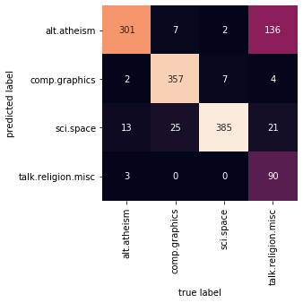

```python
from sklearn.metrics import confusion_matrix

mat = confusion_matrix(test.target, labels)

sns.heatmap(mat.T, square=True, annot=True, fmt='d', cbar=False,
            xticklabels=train.target_names, yticklabels=train.target_names)
plt.xlabel('true label')
plt.ylabel('predicted label');
```

```python
def predict_category(s, train=train, model=model):
    pred = model.predict([s])
    return train.target_names[pred[0]]
```

```python
predict_category('determining the screen resolution')
```

```
'comp.graphics'
```

```python
predict_category('sending a payload to the ISS')
```

```
'sci.space'
```

*[Reference](https://www.3pillarglobal.com/insights/document-classification-using-multinomial-naive-bayes-classifier)*

## *Why should we use Naive Bayes ?*

- *As stated above, It is easy to build and is particularly useful for very large data sets.*
- *It is extremely fast for both training and prediction.*
- *It provide straightforward probabilistic prediction.*
- *It is often very easily interpretable.*
- *It has very few (if any) tunable parameters.*
- *It perform well in case of categorical input variables compared to numerical variable(s). For numerical variable, normal distribution is assumed (bell curve, which is a strong assumption).*

## *SPAM Detection - Use Case Model*

### *Reading the data*

```python
df = pd.read_table(r'C:\Users\PiyushSin\Desktop\datasets\SMSSpamCollection',sep='\t',header=None,names=['label', 'sms_message'])

# Output printing out first 5 rows
df.head()
```

|  | label | sms_message |
| --- | --- | --- |
| 0 | ham | Go until jurong point, crazy.. Available only ... |
| 1 | ham | Ok lar... Joking wif u oni... |
| 2 | spam | Free entry in 2 a wkly comp to win FA Cup fina... |
| 3 | ham | U dun say so early hor... U c already then say... |
| 4 | ham | Nah I don't think he goes to usf, he lives aro... |

```python
df['label'] = df.label.map({'ham':0, 'spam':1})
print(df.shape)
df.head()
```

```
(5572, 2)
```

|  | label | sms_message |
| --- | --- | --- |
| 0 | 0 | Go until jurong point, crazy.. Available only ... |
| 1 | 0 | Ok lar... Joking wif u oni... |
| 2 | 1 | Free entry in 2 a wkly comp to win FA Cup fina... |
| 3 | 0 | U dun say so early hor... U c already then say... |
| 4 | 0 | Nah I don't think he goes to usf, he lives aro... |

### *Bag of Words*

*Our data set is a large collection of text data (5,572 rows of data). Most ML algorithms rely on numerical data to be fed into them as input, and email/sms messages are usually text heavy.*

*Bag of Words (BoW) concept which is a term used to specify the problems that have a collection of text data that needs to be worked with. The basic idea of BoW is to take a piece of text and count the frequency of the words in that text. It is important to note that the BoW concept treats each word individually and the order in which the words occur does not matter.*

*Using BoW, we can convert a collection of documents to a matrix, with each document being a row and each word (token) being the column, and the corresponding (row, column) values being the frequency of occurrence of each word or token in that document.*

#### *Manual BoW*

```python
# Manual Implementation of BoW

# Lower Case

documents = ['Hello, how are you!',
             'Win money, win from home.',
             'Call me now.',
             'Hello, Call hello you tomorrow?']

lower_case_documents = []
for i in documents:
    lower_case_documents.append(i.lower())

print('\n---------- Lowercase ----------')
print(lower_case_documents)

# Removing Punctuation

sans_punctuation_documents = []
import string

for i in lower_case_documents:
    sans_punctuation_documents.append(i.translate(str.maketrans('', '', string.punctuation)))

print('\n---------- Removed Punctuation ----------')
print(sans_punctuation_documents)

# Tokenization
# Tokenizing a sentence in a document set means splitting up the sentence into individual words using a delimiter.
# The delimiter specifies what character we will use to identify the beginning and end of a word. Most commonly,
# we use a single space as the delimiter character for identifying words, and this is true in our documents in this case also.

preprocessed_documents = []
for i in sans_punctuation_documents:
    preprocessed_documents.append(i.split(' '))

print('\n---------- Tokenization ----------')
print(preprocessed_documents)

# Count frequencies

frequency_list = []
import pprint
from collections import Counter

for i in preprocessed_documents:
    frequency_counts = Counter(i)
    frequency_list.append(frequency_counts)

print('\n---------- Frquency Count ----------')
pprint.pprint(frequency_list)
```

```
---------- Lowercase ----------
['hello, how are you!', 'win money, win from home.', 'call me now.', 'hello, call hello you tomorrow?']

---------- Removed Punctuation ----------
['hello how are you', 'win money win from home', 'call me now', 'hello call hello you tomorrow']

---------- Tokenization ----------
[['hello', 'how', 'are', 'you'], ['win', 'money', 'win', 'from', 'home'], ['call', 'me', 'now'], ['hello', 'call', 'hello', 'you', 'tomorrow']]

---------- Frquency Count ----------
[Counter({'hello': 1, 'how': 1, 'are': 1, 'you': 1}),
 Counter({'win': 2, 'money': 1, 'from': 1, 'home': 1}),
 Counter({'call': 1, 'me': 1, 'now': 1}),
 Counter({'hello': 2, 'call': 1, 'you': 1, 'tomorrow': 1})]
```

#### *CountVectorizer*

```python
# Using library function CountVectorizer
from sklearn.feature_extraction.text import CountVectorizer

count_vector = CountVectorizer()
print(count_vector)
```

```
CountVectorizer()
```

```python
count_vector.fit(documents)
count_vector.get_feature_names()
```

```
['are',
 'call',
 'from',
 'hello',
 'home',
 'how',
 'me',
 'money',
 'now',
 'tomorrow',
 'win',
 'you']
```

```python
doc_array = count_vector.transform(documents).toarray()
doc_array
```

```
array([[1, 0, 0, 1, 0, 1, 0, 0, 0, 0, 0, 1],
       [0, 0, 1, 0, 1, 0, 0, 1, 0, 0, 2, 0],
       [0, 1, 0, 0, 0, 0, 1, 0, 1, 0, 0, 0],
       [0, 1, 0, 2, 0, 0, 0, 0, 0, 1, 0, 1]], dtype=int64)
```

```python
frequency_matrix = pd.DataFrame(doc_array,columns = count_vector.get_feature_names())
frequency_matrix
```

|  | are | call | from | hello | home | how | me | money | now | tomorrow | win | you |
| --- | --- | --- | --- | --- | --- | --- | --- | --- | --- | --- | --- | --- |
| 0 | 1 | 0 | 0 | 1 | 0 | 1 | 0 | 0 | 0 | 0 | 0 | 1 |
| 1 | 0 | 0 | 1 | 0 | 1 | 0 | 0 | 1 | 0 | 0 | 2 | 0 |
| 2 | 0 | 1 | 0 | 0 | 0 | 0 | 1 | 0 | 1 | 0 | 0 | 0 |
| 3 | 0 | 1 | 0 | 2 | 0 | 0 | 0 | 0 | 0 | 1 | 0 | 1 |

### *Modeling*

```python
# split into training and testing sets

from sklearn.model_selection import train_test_split

X_train, X_test, y_train, y_test = train_test_split(df['sms_message'],df['label'],random_state=1)

print('Number of rows in the total set: {}'.format(df.shape[0]))
print('Number of rows in the training set: {}'.format(X_train.shape[0]))
print('Number of rows in the test set: {}'.format(X_test.shape[0]))
```

```
Number of rows in the total set: 5572
Number of rows in the training set: 4179
Number of rows in the test set: 1393
```

```python
# Instantiate the CountVectorizer method
count_vector = CountVectorizer()

# Fit the training data and then return the matrix
training_data = count_vector.fit_transform(X_train)

# Transform testing data and return the matrix. Note we are not fitting the testing data into the CountVectorizer()
testing_data = count_vector.transform(X_test)
```

```python
from sklearn.naive_bayes import MultinomialNB

naive_bayes = MultinomialNB()
naive_bayes.fit(training_data, y_train)
```

```
MultinomialNB()
```

### *Results*

```python
predictions = naive_bayes.predict(testing_data)
```

```python
predictions[0:20]
```

```
array([0, 0, 0, 0, 0, 0, 0, 0, 0, 0, 0, 0, 0, 0, 0, 0, 1, 0, 1, 0],
      dtype=int64)
```

```python
from sklearn.metrics import accuracy_score, precision_score, recall_score, f1_score

print('Accuracy score: ', format(accuracy_score(y_test, predictions)))
print('Precision score: ', format(precision_score(y_test, predictions)))
print('Recall score: ', format(recall_score(y_test, predictions)))
print('F1 score: ', format(f1_score(y_test, predictions)))
```

```
Accuracy score:  0.9885139985642498
Precision score:  0.9720670391061452
Recall score:  0.9405405405405406
F1 score:  0.9560439560439562
```